# O que o pop da Coreia tem a ver com o dos EUA

Lívia Cavalcanti e Marcus Vinícius

3 de julho de 2019

```r
library(tidyverse)
theme_set(theme_bw())
library(broom)
library(modelr)
```

```r
library(corrplot)
library(gridExtra)
```

# Os dados

```
##   danceability        energy            key          speechiness
##  Min.   :0.3510   Min.   :0.1110   Min.   : 0.000   Min.   :0.0253
##  1st Qu.:0.6195   1st Qu.:0.5968   1st Qu.: 1.000   1st Qu.:0.0443
##  Median :0.6945   Median :0.7430   Median : 5.000   Median :0.0710
##  Mean   :0.6785   Mean   :0.7030   Mean   : 4.945   Mean   :0.1022
##  3rd Qu.:0.7462   3rd Qu.:0.8520   3rd Qu.: 8.000   3rd Qu.:0.1148
##  Max.   :0.9390   Max.   :0.9640   Max.   :11.000   Max.   :0.4440
##   acousticness      instrumentalness       liveness          valence
##  Min.   :0.000155   Min.   :0.0000000   Min.   :0.02150   Min.   :0.1040
##  1st Qu.:0.030250   1st Qu.:0.0000000   1st Qu.:0.09623   1st Qu.:0.3640
##  Median :0.083000   Median :0.0000000   Median :0.13450   Median :0.5235
##  Mean   :0.181847   Mean   :0.0051416   Mean   :0.19337   Mean   :0.5295
##  3rd Qu.:0.249750   3rd Qu.:0.0000024   3rd Qu.:0.26725   3rd Qu.:0.6865
##  Max.   :0.978000   Max.   :0.3340000   Max.   :0.91600   Max.   :0.9690
##      tempo         duration_ms     time_signature  artist_name
##  Min.   : 67.93   Min.   :168840   Min.   :3.000   Length:200
##  1st Qu.:100.81   1st Qu.:196062   1st Qu.:4.000   Class :character
##  Median :121.98   Median :211362   Median :4.000   Mode  :character
##  Mean   :122.48   Mean   :215127   Mean   :3.985
##  3rd Qu.:137.58   3rd Qu.:229343   3rd Qu.:4.000
##  Max.   :205.89   Max.   :328893   Max.   :5.000
##  release_date        song_name         isExplicit       albumName
##  Length:200         Length:200         Mode :logical   Length:200
##  Class :character   Class :character   FALSE:176       Class :character
##  Mode  :character   Mode  :character   TRUE :24        Mode  :character
##
##
##
##  albumTotalTracks  totalArtists     popularity     isKPop
##  Min.   : 1.00    Min.   :1.000   Min.   :44.0   Mode :logical
##  1st Qu.: 6.00    1st Qu.:1.000   1st Qu.:63.0   FALSE:100
##  Median :11.00    Median :1.000   Median :73.5   TRUE :100
##  Mean   :10.38    Mean   :1.255   Mean   :72.2
##  3rd Qu.:14.00    3rd Qu.:1.000   3rd Qu.:80.0
##  Max.   :40.00    Max.   :3.000   Max.   :99.0
```

```
## Observations: 20
## Variables: 2
## $ artist_name <chr> "BTS", "BLACKPINK", "TWICE", "EXO", "GOT7", "Red Vel…
## $ followers   <dbl> 11847267, 7590199, 3370312, 4311282, 2545598, 234981…
```

```r
song_artist_data = inner_join(artist_followers, song_features)
```

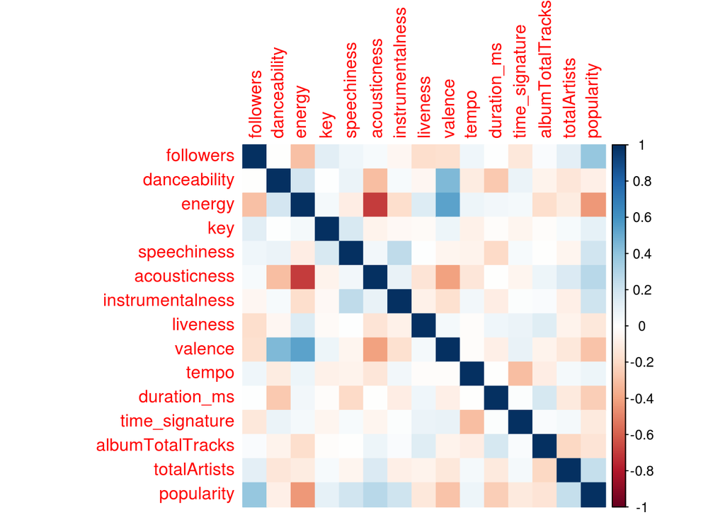

```r
temp=song_artist_data %>% select(-isKPop, -isExplicit, -albumName, -song_name, -artist_name, -release_date)
m=cor(temp)
corrplot(m, method="color")
```

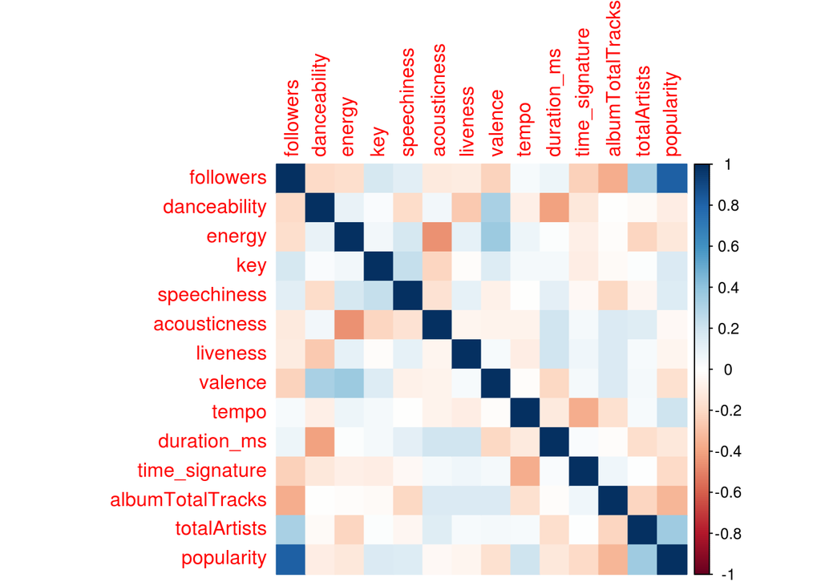

```r
kpop = song_artist_data %>% filter(isKPop=="TRUE") %>% select(-instrumentalness, -isKPop, -isExplicit) #intrumentalness ~ 0, isExplicit == FALSE
kpop_cor = kpop %>% select(-artist_name, -albumName, -song_name, -release_date)
kpop_cor = cor(kpop_cor)
corrplot(kpop_cor, method="color")
```

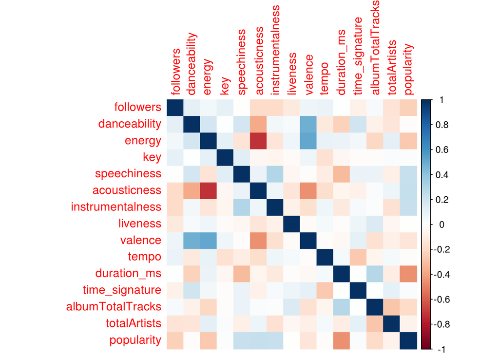

```r
apop = song_artist_data %>% filter(isKPop=="FALSE") %>% select(-isKPop)
apop_cor = apop %>% select(-artist_name, -albumName, -song_name, -release_date, -isExplicit)
apop_cor = cor(apop_cor)
corrplot(apop_cor, method="color")
```

```r
plots <- function(song_data) {
  dance<-song_data %>%
    ggplot() +
      geom_density(aes(danceability))
  tempo<-song_data %>%
    ggplot() +
    geom_density(aes(tempo))
  pop<-song_data %>%
    ggplot() +
    geom_density(aes(popularity))
  totArt <- song_data %>%
    ggplot() +
    geom_density(aes(totalArtists))
  totalTrack<-song_data %>%
    ggplot() +
    geom_density(aes(albumTotalTracks))
  energy<-song_data %>%
    ggplot() +
    geom_density(aes(energy))
  speech<-song_data %>%
    ggplot() +
    geom_density(aes(speechiness))
  acoustic <- song_data %>%
    ggplot() +
    geom_density(aes(acousticness))
  # song_data %>%
  #   ggplot() +
  #   geom_density(aes(instrumentalness))
  live <- song_data %>%
    ggplot() +
    geom_density(aes(liveness))
  val <- song_data %>%
    ggplot() +
    geom_density(aes(valence))
  dur <- song_data %>%
    ggplot() +
    geom_density(aes(duration_ms)) +
    theme(axis.text.x = element_text(angle=90))

  grid.arrange(dance, tempo, pop, totArt, totalTrack, energy, speech, acoustic, live, val, dur, nrow = 3)

}
```

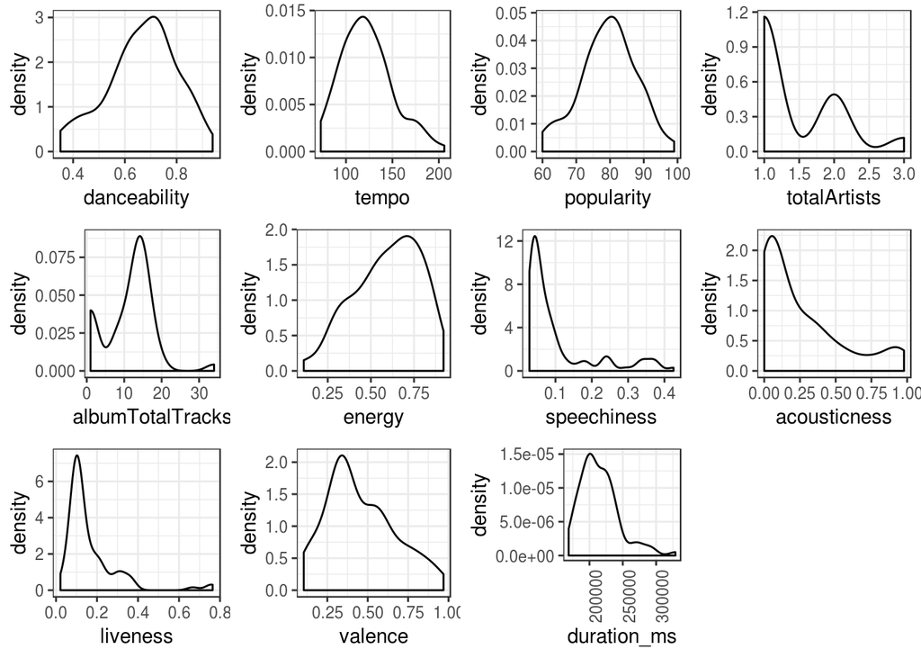

```r
plots(apop)
```

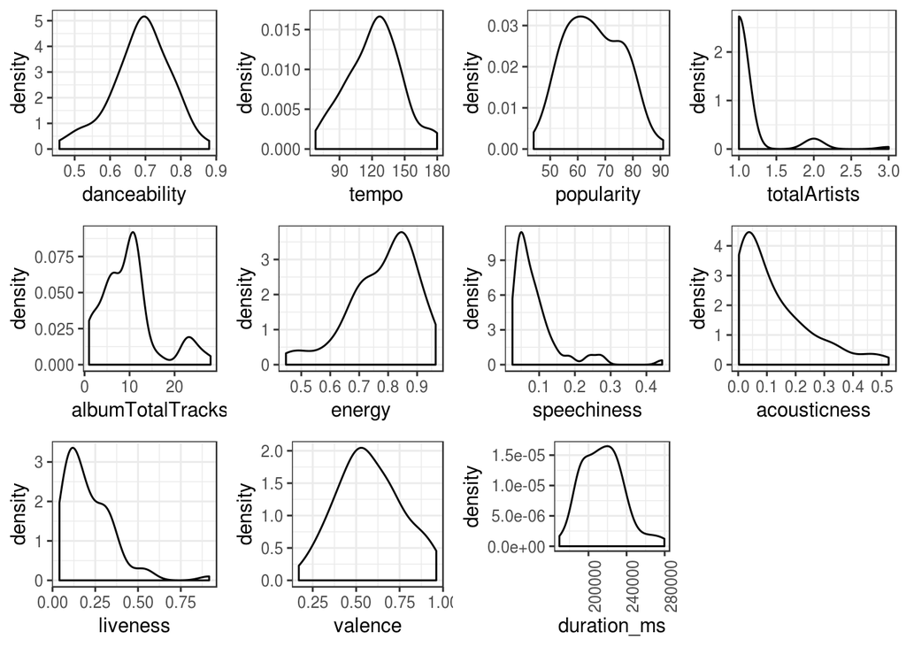

```r
plots(kpop)
```

### Análise com regressão

Nesta sessão, discutiremos quais variáveis melhor explicam a popularidade de uma música, e para isso, iremos realizar diversos experimentos utilizando regressão linear, a fim de, obter uma (ou várias) variável que explica muito bem o por que daquela música ser popular.

# Popularidade de uma música vs Tempo de duração (em milisegundos)

### PARA KPOP

Primeiramente, iremos visualizar um gráfico de pontos dessas duas variáveis para tentar traçar padrões.

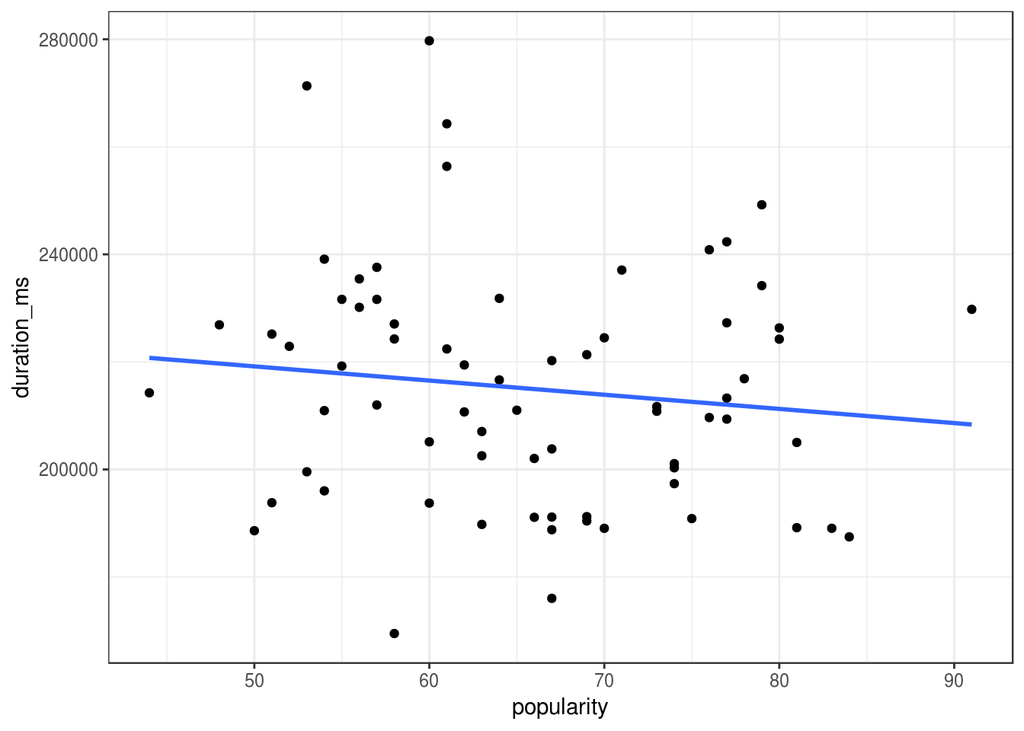

```r
kpop %>% ggplot(aes(x=popularity, y = duration_ms)) + geom_point() + geom_smooth(method = "lm", se = FALSE)
```

Podemos notar inicialmente que, a variável duração da música, a principio, não explica muito bem o por que de uma música ser popular. Vamos confirmar essa hipotése com um modelo de regressão linear.

```r
modelo_duration <- lm(popularity ~ duration_ms ,
          data = kpop)
```

Modelo obtido:

```r
tidy(modelo_duration)
```

```
## # A tibble: 2 x 5
##   term           estimate  std.error statistic      p.value
##   <chr>             <dbl>      <dbl>     <dbl>        <dbl>
## 1 (Intercept)  78.2       12.2            6.42 0.0000000157
## 2 duration_ms  -0.0000580  0.0000564     -1.03 0.308
```

Seu R²:

```r
glance(modelo_duration)
```

```
## # A tibble: 1 x 11
##   r.squared adj.r.squared sigma statistic p.value    df logLik   AIC   BIC
##       <dbl>         <dbl> <dbl>     <dbl>   <dbl> <int>  <dbl> <dbl> <dbl>
## 1    0.0153      0.000805  10.3      1.06   0.308     2  -261.  529.  536.
## # … with 2 more variables: deviance <dbl>, df.residual <int>
```

Como já desconfiavamos, a variável duração, sozinha, não explica muito o por que de uma música ser popular, e isso pode ser confirmado pelo coeficiente R² obtido na regressão linear, que nos diz que, a variável duration só explica 1% a variável popularidade.

### PARA POP AMERICANO

Primeiramente, iremos visualizar um gráfico de pontos dessas duas variáveis para tentar traçar padrões.

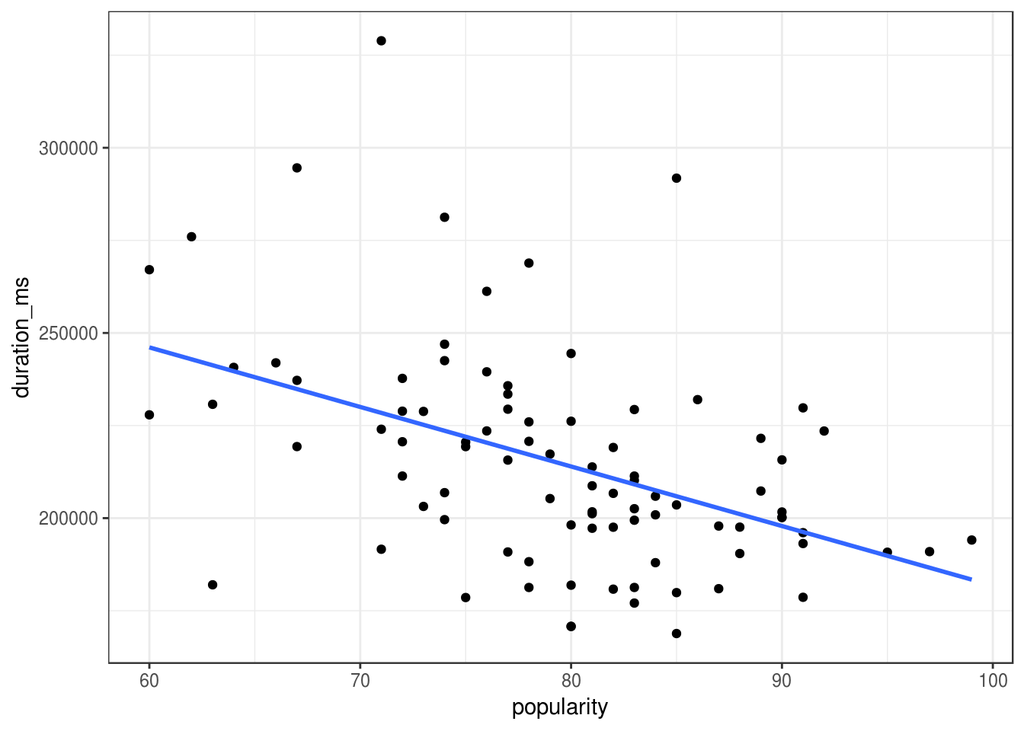

```r
apop %>% ggplot(aes(x=popularity, y = duration_ms)) + geom_point() + geom_smooth(method = "lm", se = FALSE)
```

Para as músicas populares americanas, podemos notar que, a variável duração já tem uma maior taxa de explicação sobre a variável popularidade. Vamos confirmar essa tese com um modelo de regressão linear.

```r
modelo_duration_apop <- lm(popularity ~ duration_ms ,
          data = apop)
```

Modelo obtido:

```r
tidy(modelo_duration_apop)
```

```
## # A tibble: 2 x 5
##   term           estimate std.error statistic  p.value
##   <chr>             <dbl>     <dbl>     <dbl>    <dbl>
## 1 (Intercept)  107.       5.80          18.4  6.41e-32
## 2 duration_ms   -0.000127 0.0000268     -4.76 7.47e- 6
```

Seu R²:

```r
glance(modelo_duration_apop)
```

```
## # A tibble: 1 x 11
##   r.squared adj.r.squared sigma statistic p.value    df logLik   AIC   BIC
##       <dbl>         <dbl> <dbl>     <dbl>   <dbl> <int>  <dbl> <dbl> <dbl>
## 1     0.205         0.196  7.46      22.7 7.47e-6     2  -308.  621.  629.
## # … with 2 more variables: deviance <dbl>, df.residual <int>
```

Como podemos perceber, para o cenário de músicas populares americanas, a variável duração explica muito melhor a variável popularidade do que em relação ao cenário de músicas de kpop. Essa melhoria pode ser notada pelo valor do R² obtido na regressão, que para esse cenário, explica em 20%. Por mais que esse valor ainda não seja o ideal, podemos notar uma boa mudança de valores apenas mudando as regiões (países) de interesse. É importante lembrar também que, esse valor foi obtido a partir de uma regressão linear simples, logo, existe apenas uma variável tentando explicar outra, sendo mais dificil obter valores maiores.

# Popularidade de uma música vs Nível de Acoustica

### PARA KPOP

Primeiramente, iremos visualizar um gráfico de pontos dessas duas variáveis para tentar traçar padrões.

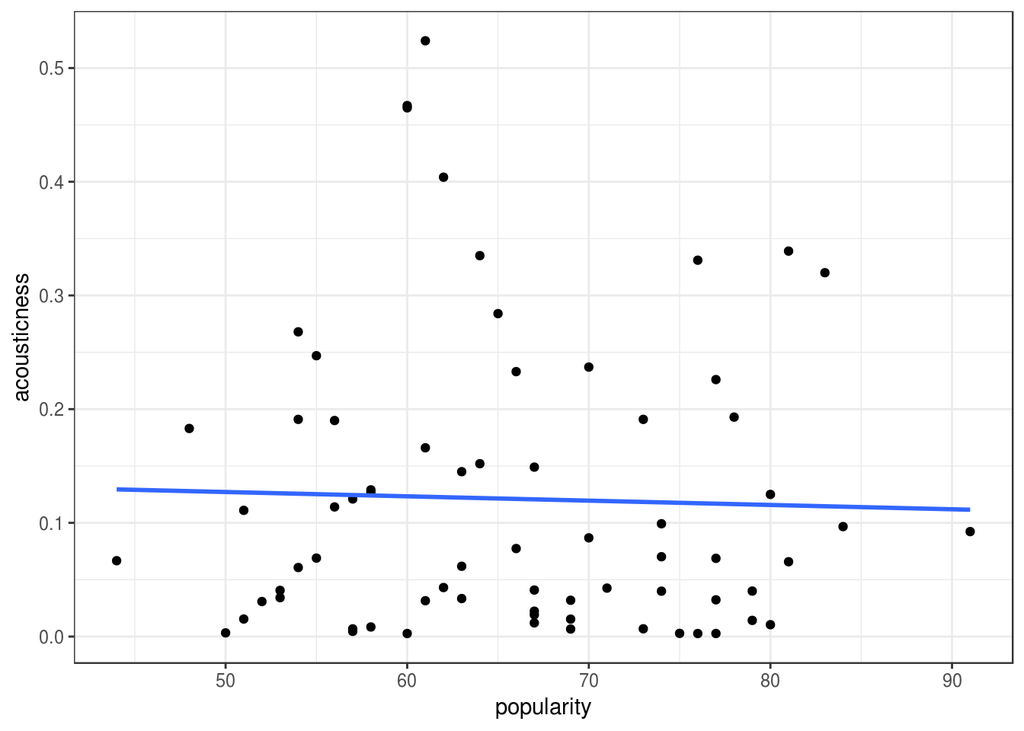

```r
kpop %>% ggplot(aes(x=popularity, y = acousticness)) + geom_point() + geom_smooth(method = "lm", se = FALSE)
```

Podemos notar inicialmente que, a variável acousticness, que nos diz uma escala entre [0-1] não possui um bom teor de explicação sobre a variável popularidade, e isso pode ser percebido pela reta de regressão feita no gráfico, que não divide muito bem os pontos. Para confirmar essa tese, faremos o modelo de regressão abaixo.

```r
modelo_acousticness <- lm(popularity ~ acousticness ,
          data = kpop)
```

Modelo obtido:

```r
tidy(modelo_acousticness)
```

```
## # A tibble: 2 x 5
##   term         estimate std.error statistic  p.value
##   <chr>           <dbl>     <dbl>     <dbl>    <dbl>
## 1 (Intercept)     66.1       1.72    38.5   7.21e-48
## 2 acousticness    -2.50      9.83    -0.254 8.00e- 1
```

Seu R²:

```r
glance(modelo_acousticness)
```

```
## # A tibble: 1 x 11
##   r.squared adj.r.squared sigma statistic p.value    df logLik   AIC   BIC
##       <dbl>         <dbl> <dbl>     <dbl>   <dbl> <int>  <dbl> <dbl> <dbl>
## 1  0.000949       -0.0137  10.4    0.0646   0.800     2  -262.  530.  537.
## # … with 2 more variables: deviance <dbl>, df.residual <int>
```

Como já desconfiavamos, a variável acousticness se mostrou péssima para explicar a variável de popularidade de uma música, essa confirmação pode ser notada pelo valor do R² obtido, que é extremamente baixo. A conclusão que obtemos é, para o cenário de Kpop, uma música ser inteiramente acoustica ou inteiramente não-acoustica não influencia muito na sua popularidade.

### PARA POP AMERICANO

Primeiramente, iremos visualizar um gráfico de pontos dessas duas variáveis para tentar traçar padrões.

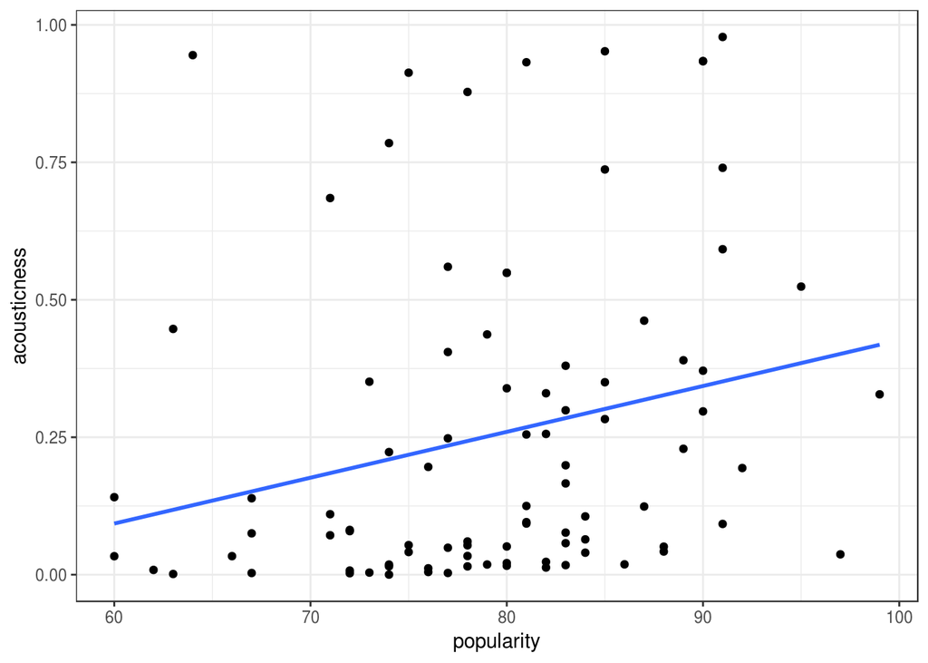

```r
apop %>% ggplot(aes(x=popularity, y = acousticness)) + geom_point() + geom_smooth(method = "lm", se = FALSE)
```

Por mais que, aparentemente a variável ainda não demonstre ter um bom teor de explicação sobre a variável popularidade, podemos ver que para o cenário de músicas populares americanas, essa variável já consegue, aparentemente, explicar um pouco melhor em relação ao cenário de kpop. Confirmaremos abaixo.

```r
modelo_acousticness_apop <- lm(popularity ~ acousticness ,
          data = apop)
```

Modelo obtido:

```r
tidy(modelo_acousticness_apop)
```

```
## # A tibble: 2 x 5
##   term         estimate std.error statistic  p.value
##   <chr>           <dbl>     <dbl>     <dbl>    <dbl>
## 1 (Intercept)     77.7       1.14     68.0  7.54e-78
## 2 acousticness     6.85      2.97      2.31 2.33e- 2
```

Seu R²:

```r
glance(modelo_acousticness_apop)
```

```
## # A tibble: 1 x 11
##   r.squared adj.r.squared sigma statistic p.value    df logLik   AIC   BIC
##       <dbl>         <dbl> <dbl>     <dbl>   <dbl> <int>  <dbl> <dbl> <dbl>
## 1    0.0571        0.0464  8.12      5.33  0.0233     2  -315.  636.  644.
## # … with 2 more variables: deviance <dbl>, df.residual <int>
```

Como podemos perceber, para o cenário de músicas populares americanas, a variável acousticness continua bastante inexpressiva para sua função (5% de explicação, segundo o R²), que é explicar a variável popularidade de uma música, no entanto, cumpre seu papel com mais eficácia nos dados de músicas populares americanas. A conclusão geral é, em ambos os cenários (kpop e apop), essa variável se mostrou bastante fraca para explicar o quão popular uma música é.